# Assignment Week 3

### Name: Yizhen Dai

### ULCN: S2395479

We will compute or approximate the value of the expectation
$$I=E[\mathbb{1}(X > 1) X^2], \qquad X \sim \mathcal N(0, 1).$$

### Exercise 1. Importance sampling

- Obtain a Monte Carlo estimate of $I$ using importance sampling. (There are multiple solutions; make sure that your method is substantially more efficient than straightforward simulation from a normal distribution with mean zero.)

```r
set.seed(1234)

N <- 10^4 # MC replications

MC_IS <- function(N) { # Importance sampling
  Z <- rnorm(N, mean = 1) # the alternative distribution
  G <- as.integer(Z>1) * Z ^ 2 # calculate I(X)
  mean(G * dnorm(Z) / dnorm(Z, mean = 1))
}

MC_IS(N)
```

```
## [1] 0.402201
```

- Calculate the MC approximation error. Firstly, we calculate the theoretical value of $I$.
  $$I = \int_{-\infty}^10\,dx + \int_1^{\infty} x^2f(x)\,dx \\
  = \int_1^{\infty} \frac{x^2e^{-x^2/2}}{\sqrt{2\pi}}\,dx$$

```r
integrand <- function(x) {x^2*exp(-x^2/2)/sqrt(2*pi)}
# integrate the function from 1 to infinity
I_true <- integrate(integrand, lower = 1, upper = Inf)
I_true
```

```
## 0.400626 with absolute error < 5.7e-07
```

```r
err_IS <- replicate(10^3, MC_IS(N)) - I_true$value
RMSE_IS <- sqrt(mean(err_IS)^2)
format(RMSE_IS, scientific = TRUE)
```

```
## [1] "4.213091e-05"
```

The MC approximation error is $4.21 * 10^{-5}$.

### Exercise 2. Antithetic variables

- This time use antithetic variables for computing $I$.

```r
set.seed(1234)

MC_AT <- function(N) { # Antithetic variables
  U <- runif(N/2)
  Z <- c(qnorm(U), qnorm(1 - U))
  G <- as.integer(Z>1) * Z ^ 2 # calculate I(X)
  mean(G)
}

MC_AT(N)
```

```
## [1] 0.4051495
```

- Estimate the MC approximation error using simulation. Compare this to importance sampling.

```r
err_AT <- replicate(10^3, MC_AT(N)) - I_true$value
RMSE_AT <- sqrt(mean(err_AT)^2)
format(RMSE_AT, scientific = TRUE)
```

```
## [1] "5.994821e-04"
```

The MC approximation error for Antithetic variables is $5.995 * 10^{-4}$, which is about 10 times of the error for Importance sampling. Importance sampling is much more effcicent in this case.

- Now combine antithetic variables with importance sampling to achieve maximal accuracy.

```r
set.seed(1234)

MC_AT_IS <- function(N) {
  U <- runif(N/2) # prepare for Antithetic variables
  Z <- c( qnorm(U, mean = 1), qnorm(1 - U, mean = 1)) # the alternative distribution
  G <- as.integer(Z>1) * Z ^ 2 # calculate I(X)
  mean(G * dnorm(Z) / dnorm(Z, mean = 1))
}

MC_AT_IS(N)
```

```
## [1] 0.3995456
```

- Compute the MC approximation error and compare to the previous methods.

```r
err_AT_IS <- replicate(10^3, MC_AT_IS(N)) - I_true$value
RMSE_AT_IS <-  sqrt(mean(err_AT_IS)^2)
format(RMSE_AT_IS, scientific = TRUE)
```

```
## [1] "2.744768e-05"
```

The MC approximation error for the combined methods is $2.74 * 10^{-5}$, which is the smallest among the results from three methods. Using both methods together does increase the simulation efficiency.

### Exercise 3. Metropolis-Hastings

Let $f(x)=(2+\sin(1/x))\exp(-x^2)$.

- Use the Metropolis-Hastings algorithm to sample from the distribution with density proportional to $f$, and plot a histogram. Use a suitable proposal distribution.

> Mixing is strongly affected by features of the proposal distribution, especially its spread. For a general Metropolis–Hastings chain such as an independence chain, it seems intuitively clear that we wish the proposal distribution g to approximate the target distribution f very well, which in turn suggests that a very high rate of accepting proposals is desirable. In practice, the variance of the proposal distribution can be selected through an informal iterative process. Start a chain, and monitor the proportion of proposals that have been accepted; then adjust the spread of the proposal distribution accordingly. For a Metropolis algorithm with normal target and proposal distributions, it has been suggested that an acceptance rate of between 25 and 50% should be preferred, with the best choice being about 44% for one-dimensional problems

[Ref: G. H. Givens and J. A. Hoeting. Computational Statistics. Wiley, New Jersey, 2005.]

```r
# Start with normal distribution as proposal distribution
set.seed(1234)

N <- 10^5
sigma <- 1.5
f <- function(x) (2+sin(1/x))/exp(x^2)
g <- function(x) rnorm(1, x, sigma)

x <- numeric(N)
x[1] <- g(0)
k <- 0
u <- runif(N)

for (i in 2:N) {
  xt <- x[i-1]
  y <- g(xt)
  num <- f(y) * dnorm(xt, y, sigma)
  den <- f(xt) * dnorm(y, xt, sigma)
  if (u[i] <= num/den) x[i] <- y else {
  x[i] <- xt
  k <- k+1
  }
}

x <- x[-c(1:1000)] # burn the first 1000 iterations

1 - k/(N-10^3) # acceptance rate
```

```
## [1] 0.4284646
```

Around 42% of the candidate points are accepted. Next we examine the stochastic process after the burn-in period

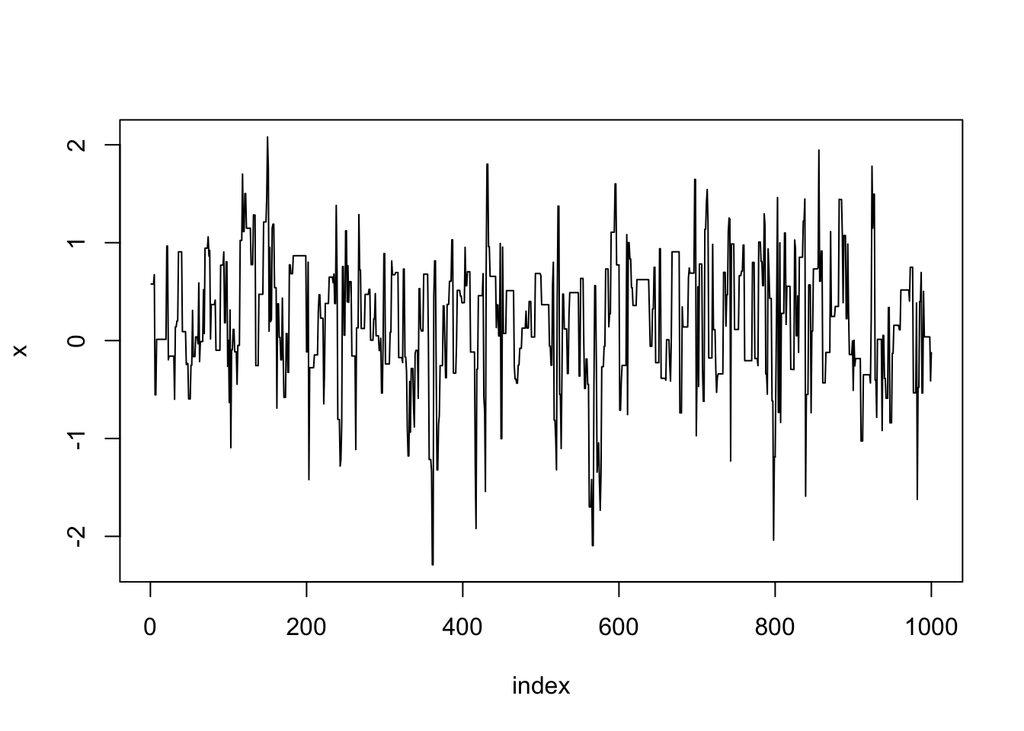

```r
index <- 1:1000
y1 <- x[index]
plot(index, y1, type="l", main="", ylab="x")
```

The number of thrown-away burn-in samples seems reasonable.

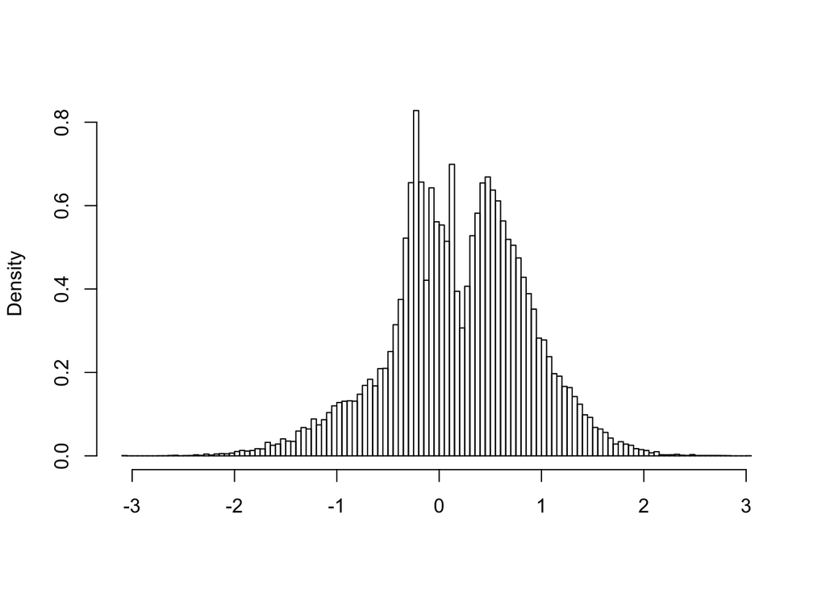

```r
hist(x,breaks="scott", main="", xlab="", freq=FALSE)
```